# Storm event impacts in the USA between 1950 and 2011

Philip Massie

30 June 2016

## Synopsis

This analysis set out to answer the following questions:

1. Across the United States, which types of events are most harmful with respect to population health?
2. Across the United States, which types of events have the greatest economic consequences?

The findings suggest that tornados play the largest roles in terms of both human health and economic consequences. Tornados are the most costly in both categories accounting for 5633 deaths, 91346 injuries as well as $52 167 160 779 damage to property and $414 953 270 damage to crops. Thunderstorms had the second largest impacts in terms of human health (701 deaths and 9363 injuries) while flooding accounted for the second largest economic impacts($34 407 709 807 damage to property, $5 661 968 450 damage to crops).

## Data Processing

Initially the compressed data file was downloaded from the Coursera course repository. The data file, StormData.csv was then extracted from the compressed file StormData.csv.bz2 and stored in the R data frame ‘storm.data’ (hereafter referred to as ‘the data’).

A brief analysis of the data revealed that the variables ‘FATALITIES’ and ‘INJURIES’ would relate to population health and the variables ‘PROPDMG’ and ‘CROPDMG’ would relate to economic consequences.

```r
## Prerequisites
# setwd("D:/My Folders/R/2016/coursera/data_science/mod_5_week_4")
# download file and extract data
# download.file("https://d396qusza40orc.cloudfront.net/repdata/data/StormData.csv.bz2", "StormData.csv.bz2")
# file downloaded 2016/06/30 15:45
storm.data <- read.csv("StormData.csv.bz2")
head(storm.data)
```

```
##   STATE__           BGN_DATE BGN_TIME TIME_ZONE COUNTY COUNTYNAME STATE
## 1       1  4/18/1950 0:00:00     0130       CST     97     MOBILE    AL
## 2       1  4/18/1950 0:00:00     0145       CST      3    BALDWIN    AL
## 3       1  2/20/1951 0:00:00     1600       CST     57    FAYETTE    AL
## 4       1   6/8/1951 0:00:00     0900       CST     89    MADISON    AL
## 5       1 11/15/1951 0:00:00     1500       CST     43    CULLMAN    AL
## 6       1 11/15/1951 0:00:00     2000       CST     77 LAUDERDALE    AL
##    EVTYPE BGN_RANGE BGN_AZI BGN_LOCATI END_DATE END_TIME COUNTY_END
## 1 TORNADO         0                                               0
## 2 TORNADO         0                                               0
## 3 TORNADO         0                                               0
## 4 TORNADO         0                                               0
## 5 TORNADO         0                                               0
## 6 TORNADO         0                                               0
##   COUNTYENDN END_RANGE END_AZI END_LOCATI LENGTH WIDTH F MAG FATALITIES
```

[output cut: 20 more lines]

```r
# Check the time frames
library(stringr)

storm.data$BGN_DATE <- as.POSIXct(as.Date(str_sub(storm.data$BGN_DATE, start = 1L, end = -9L), format = "%m/%d/%Y"))
min(storm.data$BGN_DATE)
```

```
## [1] "1950-01-03 02:00:00 SAST"
```

```r
max(storm.data$BGN_DATE)
```

```
## [1] "2011-11-30 02:00:00 SAST"
```

```r
# Process the damage costs
# The costs need to be multiplied by an exponent specified in the accompanying EXP column.
unique(storm.data$PROPDMGEXP)
```

```
##  [1] K M   B m + 0 5 6 ? 4 2 3 h 7 H - 1 8
## Levels:  - ? + 0 1 2 3 4 5 6 7 8 B h H K m M
```

```r
ind.b <- which(storm.data$PROPDMGEXP == "B") #Billions
ind.m <- which(storm.data$PROPDMGEXP == "m" | storm.data$PROPDMGEXP == "M") # Millions
ind.k <- which(storm.data$PROPDMGEXP == "K") #Thousands
ind.h <- which(storm.data$PROPDMGEXP == "h" | storm.data$PROPDMGEXP == "H") # Hundreds

storm.data$PROPDMG[ind.b] <- storm.data$PROPDMG[ind.b] * 100000000
storm.data$PROPDMG[ind.m] <- storm.data$PROPDMG[ind.m] * 1000000
storm.data$PROPDMG[ind.k] <- storm.data$PROPDMG[ind.k] * 1000
storm.data$PROPDMG[ind.h] <- storm.data$PROPDMG[ind.h] * 100

unique(storm.data$CROPDMGEXP)
```

```
## [1]   M K m B ? 0 k 2
## Levels:  ? 0 2 B k K m M
```

```r
ind.b <- which(storm.data$CROPDMGEXP == "B") #Billions
ind.m <- which(storm.data$CROPDMGEXP == "m" | storm.data$CROPDMGEXP == "M") # Millions
ind.k <- which(storm.data$CROPDMGEXP == "k" | storm.data$CROPDMGEXP == "K") #Thousands

storm.data$CROPDMG[ind.b] <- storm.data$CROPDMG[ind.b] * 100000000
storm.data$CROPDMG[ind.m] <- storm.data$CROPDMG[ind.m] * 1000000
storm.data$CROPDMG[ind.k] <- storm.data$CROPDMG[ind.k] * 1000
```

The data were then subset to include only the following variables: ‘EVTYPE’, ‘FATALITIES’, ‘INJURIES’, ‘PROPDMG’ and ‘CROPDMG’ for the sake of simplicity.

```r
# Subset the full dataframe to include only the columns of interest
names(storm.data)
```

```
##  [1] "STATE__"    "BGN_DATE"   "BGN_TIME"   "TIME_ZONE"  "COUNTY"
##  [6] "COUNTYNAME" "STATE"      "EVTYPE"     "BGN_RANGE"  "BGN_AZI"
## [11] "BGN_LOCATI" "END_DATE"   "END_TIME"   "COUNTY_END" "COUNTYENDN"
## [16] "END_RANGE"  "END_AZI"    "END_LOCATI" "LENGTH"     "WIDTH"
## [21] "F"          "MAG"        "FATALITIES" "INJURIES"   "PROPDMG"
## [26] "PROPDMGEXP" "CROPDMG"    "CROPDMGEXP" "WFO"        "STATEOFFIC"
## [31] "ZONENAMES"  "LATITUDE"   "LONGITUDE"  "LATITUDE_E" "LONGITUDE_"
## [36] "REMARKS"    "REFNUM"
```

```r
storm.data <- storm.data[, c("EVTYPE", "FATALITIES", "INJURIES", "PROPDMG", "CROPDMG")]
```

*Event type processing*

The referenced document ‘NATIONAL WEATHER SERVICE INSTRUCTION 10-1605’ (hereafter referred to as ‘the document’) refers to 48 storm event categories while the variable ‘EVTYPE’ contains 985 unique event types. Further examination of ‘EVTYPE’ revealed that the variable contained many discrepancies, result of spelling errors (e.g. ‘High Windss’), contractions (e.g. ‘Tstm Wind’) plurals (‘Rip Currents’) and other similar mistakes. The following efforts were made to reduce and refine this variable.

Leading and training whitespace were trimmed from the variable entries, double spaces were replaced with single spaces and cases were changed to sentence case. A vector containing the 48 event types found in the document was generated. The only alteration made was from ‘Hurricane (Typhoon)’ to ‘Hurricane/Typhoon’ for matching purposes. A variable named ‘in.doc’ was added to the data containing a Boolean indicator as to whether each ‘EVTYPE’ was listed in the document. Using this column, it was determined that ‘EVTYPEs’ not mentioned in the document, did contribute to the most harmful to health and economically consequential categories. They were therefore not exluded from this analysis.

Further refinement was not undertaken onthe remining ‘EVTYPE’ errors. It was determined that it was unlikely that they would contribute any meaninful impact to this analysis.

```r
# take a look at the data
head(storm.data)
```

```
##    EVTYPE FATALITIES INJURIES PROPDMG CROPDMG
## 1 TORNADO          0       15   25000       0
## 2 TORNADO          0        0    2500       0
## 3 TORNADO          0        2   25000       0
## 4 TORNADO          0        2    2500       0
## 5 TORNADO          0        2    2500       0
## 6 TORNADO          0        6    2500       0
```

```r
summary(storm.data)
```

```
##                EVTYPE         FATALITIES          INJURIES
##  HAIL             :288661   Min.   :  0.0000   Min.   :   0.0000
##  TSTM WIND        :219940   1st Qu.:  0.0000   1st Qu.:   0.0000
##  THUNDERSTORM WIND: 82563   Median :  0.0000   Median :   0.0000
##  TORNADO          : 60652   Mean   :  0.0168   Mean   :   0.1557
##  FLASH FLOOD      : 54277   3rd Qu.:  0.0000   3rd Qu.:   0.0000
##  FLOOD            : 25326   Max.   :583.0000   Max.   :1700.0000
##  (Other)          :170878
##     PROPDMG             CROPDMG
##  Min.   :0.000e+00   Min.   :        0
##  1st Qu.:0.000e+00   1st Qu.:        0
##  Median :0.000e+00   Median :        0
##  Mean   :1.984e+05   Mean   :    40846
##  3rd Qu.:5.000e+02   3rd Qu.:        0
##  Max.   :1.150e+10   Max.   :596000000
##
```

```r
## Tidy up the event type names.
# There are some duplicates so this process shortens the list somewhat too.
length(unique(storm.data$EVTYPE))
```

```
## [1] 985
```

```r
# trim whitespace from messy event type names
storm.data$EVTYPE <- trimws(storm.data$EVTYPE, "both")

# replace double spaces with singles
storm.data$EVTYPE <- str_replace_all(storm.data$EVTYPE, "  ", " ")

# fix the case of messy event names for better plotting
storm.data$EVTYPE <- str_to_title(storm.data$EVTYPE)

# These corrections were determined by iteratively evaluating the top 20 of both injury.data and damage.data
# To see the uncorrected data simply dont run these three corrections
storm.data$EVTYPE[which(storm.data$EVTYPE == "Tstm Wind" | storm.data$EVTYPE == "Thunderstorm Winds")] <- "Thunderstorm Wind"
storm.data$EVTYPE[which(storm.data$EVTYPE == "Rip Currents")] <- "Rip Current"
storm.data$EVTYPE[which(storm.data$EVTYPE == "High Winds")] <- "High Wind"
```

The data were grouped by ‘EVTYPE’. The individual, cumulative values for ‘FATALITIES’ and ‘INJURIES’ were summed for each ‘EVTYPE’ and saved to a data.frame called injury.data. ‘PROPDMG’ and ‘CROPDMG’ data were similarly processed into a data frame named damage.data. In both cases the total injury/damage per event type was determined by summing the data, and this column was used to sort the new data frames in descending order. Event types with totals of zero were removed. Visual inspection of the resulting revealed that the top 10 contributors adequately represented the primary contributors. The top 10 contributing ‘EVTYPEs’ in each category were visually inspected and the following corrections were made in order to correct obvious mistakes and repetitions in these contributors.

1. ‘Tstm Wind’ and ‘Thunderstorm Winds’ were replaced with ‘Thunderstorm Wind’
2. ‘Rip Currents’ was replaced with ‘Rip Current’
3. ‘High Winds’ was replaced with ‘High Wind’

These corrections were determined iteratively and applied retroactively to the above processing pipeline.

```r
# Check which names in data set match names in Doc
# Changed 'Hurricane (Typhooon)' to 'Hurricane/Typhoon' to match data set
event.names.in.doc <- c('Astronomical Low Tide', 'Avalanche', 'Blizzard', 'Coastal Flood', 'Cold/Wind Chill', 'Debris Flow', 'Dense Fog', 'Dense Smoke', 'Drought', 'Dust Devil', 'Dust Storm', 'Excessive Heat', 'Extreme Cold/Wind Chill', 'Flash Flood', 'Flood', 'Frost/Freeze', 'Funnel Cloud', 'Freezing Fog', 'Hail', 'Heat', 'Heavy Rain', 'Heavy Snow', 'High Surf', 'High Wind', 'Hurricane/Typhoon', 'Ice Storm', 'Lake-Effect Snow', 'Lakeshore Flood', 'Lightning', 'Marine Hail', 'Marine High Wind', 'Marine Strong Wind', 'Marine Thunderstorm Wind', 'Rip Current', 'Seiche', 'Sleet', 'Storm Surge/Tide', 'Strong Wind',  'Thunderstorm Wind', 'Tornado', 'Tropical Depression', 'Tropical Storm', 'Tsunami', 'Volcanic Ash', 'Waterspout', 'Wildfire', 'Winter Storm', 'Winter Weather')

# This function aggregates and sorts the data
data.separator <- function(col1, col2) {
    storm.data$in.doc <- sapply(storm.data$EVTYPE, function(x) if (x %in% event.names.in.doc) {return(TRUE)} else {return(FALSE)})
    stemp <- aggregate(cbind(col1, col2) ~ EVTYPE + in.doc, storm.data, sum)
    # 2. sum the impacts
    stemp$tot <- stemp$col1 + stemp$col2
    # 3. sort by the total impact
    stemp <- stemp[order(-stemp$tot), ]
    # tidy up the row names
    row.names(stemp) <- NULL
    names(stemp)[c(3,4)] <- c(str_to_title(substitute(col1)),str_to_title(substitute(col2)))
    stemp <- stemp[(stemp$tot != 0) ,]
    return(stemp)
}

injury.data <- with(storm.data, data.separator(FATALITIES, INJURIES))
damage.data <- with(storm.data, data.separator(PROPDMG, CROPDMG))

# check out the to 20 for obvious errors
head(injury.data, 20)
```

```
##               EVTYPE in.doc Fatalities Injuries   tot
## 1            Tornado   TRUE       5633    91346 96979
## 2  Thunderstorm Wind   TRUE        701     9363 10064
## 3     Excessive Heat   TRUE       1903     6525  8428
## 4              Flood   TRUE        470     6789  7259
## 5          Lightning   TRUE        816     5230  6046
## 6               Heat   TRUE        937     2100  3037
## 7        Flash Flood   TRUE        978     1777  2755
## 8          Ice Storm   TRUE         89     1975  2064
## 9          High Wind   TRUE        283     1439  1722
## 10      Winter Storm   TRUE        206     1321  1527
## 11              Hail   TRUE         15     1361  1376
## 12 Hurricane/Typhoon   TRUE         64     1275  1339
## 13        Heavy Snow   TRUE        127     1021  1148
## 14       Rip Current   TRUE        572      529  1101
## 15          Wildfire   TRUE         75      911   986
## 16          Blizzard   TRUE        101      805   906
## 17               Fog  FALSE         62      734   796
## 18  Wild/Forest Fire  FALSE         12      545   557
## 19         Heat Wave  FALSE        172      379   551
## 20        Dust Storm   TRUE         22      440   462
```

```r
head(damage.data, 20)
```

```
##               EVTYPE in.doc     Propdmg     Cropdmg         tot
## 1            Tornado   TRUE 52167160779   414953270 52582114049
## 2              Flood   TRUE 34407709807  5661968450 40069678257
## 3               Hail   TRUE 14112267543  3025954473 17138222016
## 4        Flash Flood   TRUE 15240862067  1421317100 16662179167
## 5            Drought   TRUE  1046106000 12622566000 13668672000
## 6  Hurricane/Typhoon   TRUE 10355840000  1248872800 11604712800
## 7  Thunderstorm Wind   TRUE  9712165782  1159505188 10871670970
## 8          Hurricane  FALSE  6738319010  2741910000  9480229010
## 9          High Wind   TRUE  4708373043   679291900  5387664943
## 10       Storm Surge  FALSE  5019536000        5000  5019541000
## 11         Ice Storm   TRUE  3944927860   522113500  4467041360
## 12          Wildfire   TRUE  3829114000   295472800  4124586800
## 13    Tropical Storm   TRUE  3068890550   678346000  3747236550
## 14      Winter Storm   TRUE  2188497251    26944000  2215441251
## 15  Wild/Forest Fire  FALSE  1651829500   106796830  1758626330
## 16        Heavy Rain   TRUE   694248090   733399800  1427647890
## 17      Extreme Cold  FALSE    67737400  1312973000  1380710400
## 18       River Flood  FALSE   618945500   529459000  1148404500
## 19      Frost/Freeze   TRUE    10480000  1094186000  1104666000
## 20        Heavy Snow   TRUE   932589142   134653100  1067242242
```

```r
# plot(injury.data$tot[1:100])
# plot(damage.data$tot[1:100])

# # Are there any values in event.names.in.doc which arent mentioned in EVTYPE?
# # only missing is "Debris Flow"
# event_names[!(event.names.doc %in% storm.data$EVTYPE)]
```

## Results

Prepare the data for plotting.

```r
library(ggplot2)
library(reshape2)

injury.data <- injury.data[1:10, ]
injury.data.mlt <- melt(injury.data, "EVTYPE", measure.vars = c('Fatalities', 'Injuries'))

damage.data <- damage.data[1:10, ]
names(damage.data)[c(3,4)] <- c('Property Damage', 'Crop Damage')
damage.data.mlt <- melt(damage.data, "EVTYPE", measure.vars = c('Property Damage', 'Crop Damage'))
damage.data.mlt$value <- damage.data.mlt$value/1000000000
```

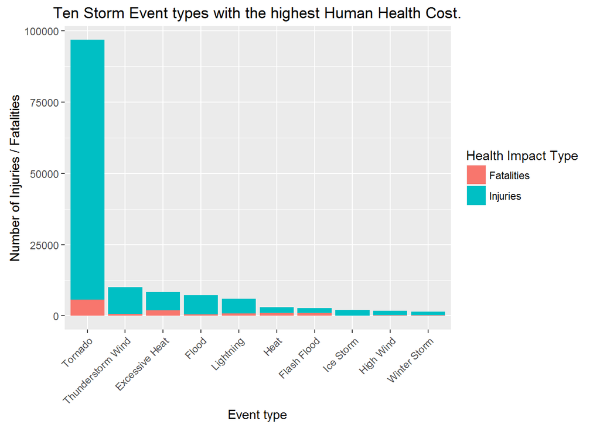

```r
ggplot(injury.data.mlt, aes(x = reorder(EVTYPE, -value), y = value, fill = variable)) + geom_bar(stat="identity") +
    theme(axis.text.x=element_text(angle=45,hjust=1)) +
    labs(title="Ten Storm Event types with the highest Human Health Cost.", x = "Event type", y = "Number of Injuries / Fatalities") +
    guides(fill=guide_legend(title="Health Impact Type"))
```

*Figure 1:* *The numbers of Injuries and fatalities associated with the ten most damaging storm event types in the USA. By far the most harm is caused by tornados with the next biggest contributor, thunderstorm wind generating only a small fraction of comparitively harm.*

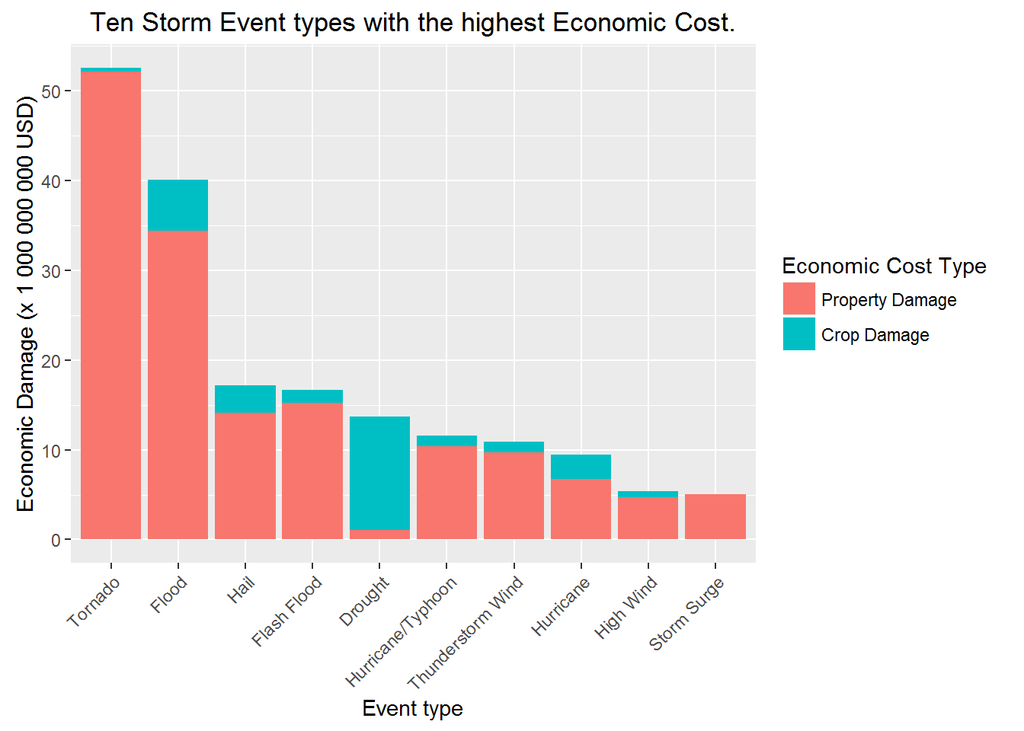

```r
ggplot(damage.data.mlt, aes(x = reorder(EVTYPE, -value), y = value, fill = variable)) + geom_bar(stat="identity") +
    theme(axis.text.x=element_text(angle=45,hjust=1)) +
    labs(title="Ten Storm Event types with the highest Economic Cost.", x = "Event type", y = "Economic Damage (x 1 000 000 000 USD)") +
    guides(fill=guide_legend(title="Economic Cost Type"))
```

*Figure 2:* *The economic cost in USD of the ten most destructive, storm related contributors in the USA. tornados and floods are the major contributors. There is less of a relative discrepancy between the two most destructive economic impacts than for human impacts.*